# Stroke Prediction Dataset Analysis and Visualization

## Data Set Characteristics:

### Name:

Stroke Prediction dataset from Kaggle URL: https://www.kaggle.com/fedesoriano/stroke-prediction-dataset

### Potential Goal:

This dataset is used to predict whether a patient is likely to get stroke based on the input parameters like gender, age, various diseases, and smoking status. Each row in the data provides relavant information about the patient.

```
:Features: 12 clinical features

:Number of Instances: 5110

:Number of Attributes: 12 numeric/categorical predictive.

:Attribute Information (in order):

    1) id: unique identifier
    2) gender: "Male", "Female" or "Other"
    3) age: age of the patient
    4) hypertension: 0 if the patient doesn't have hypertension, 1 if the patient has hypertension
    5) heart_disease: 0 if the patient doesn't have any heart diseases, 1 if the patient has a heart disease
    6) ever_married: "No" or "Yes"
    7) work_type: "children", "Govt_jov", "Never_worked", "Private" or "Self-employed"
    8) Residence_type: "Rural" or "Urban"
    9) avg_glucose_level: average glucose level in blood
    10) bmi: body mass index
    11) smoking_status: "formerly smoked", "never smoked", "smokes" or "Unknown"*
    12) stroke: 1 if the patient had a stroke or 0 if not
```

### Import Libraries

```python
import os
import numpy as np
import pandas as pd
import matplotlib.pyplot as plt
from sklearn.model_selection import train_test_split
import seaborn as sns
from sklearn.neighbors import KNeighborsClassifier
from sklearn.preprocessing import StandardScaler
from sklearn.preprocessing import LabelEncoder
from sklearn.linear_model import LogisticRegression
from sklearn.metrics import mean_squared_error, r2_score
import sklearn.metrics as sk
from sklearn import tree
from sklearn.ensemble import RandomForestClassifier
from lime import lime_tabular
import random
from IPython.display import HTML
from sklearn.metrics import classification_report, confusion_matrix
```

### Constants

```python
FILE = 'healthcare-dataset-stroke-data'
RANDOM_STATE = 7
TEST_SIZE = 0.3
COLUMN_HEADING = ["Model", "TP", "FP", "TN", "FN", "TPR", "TNR", "Accuracy%"]
classifier_summary_dataset = []
classifier_summary_dataset.append(COLUMN_HEADING)
```

### Load healthcare stroke dataset

```python
try:
    df_data_stroke = pd.read_csv("./healthcare-dataset-stroke-data.csv")

except Exception as e:
    print(e)
    print('failed to read data for ', FILE)
```

### Data preprocessing:

#### remove rows with missing values and remove 'other' from gender since there is only 1 row with gender = other

```python
df_data_stroke = df_data_stroke.dropna()
df_data_stroke.drop(df_data_stroke[df_data_stroke['gender'] == 'Other'].index, inplace = True)
```

#### Add a label column with 'yes' value if stroke = 1 and 'no' value if stroke = 0

```python
def add_True_label(df_data, column, feature):
   df_data_stroke[column] = df_data[feature].apply(lambda x : 'yes' if x == 1 else 'no')

add_True_label(df_data_stroke,'stroke label', 'stroke')
df_data_stroke.head()
```

|  | id | gender | age | hypertension | heart_disease | ever_married | work_type | Residence_type | avg_glucose_level | bmi | smoking_status | stroke | stroke label |
| --- | --- | --- | --- | --- | --- | --- | --- | --- | --- | --- | --- | --- | --- |
| 0 | 9046 | Male | 67.0 | 0 | 1 | Yes | Private | Urban | 228.69 | 36.6 | formerly smoked | 1 | yes |
| 2 | 31112 | Male | 80.0 | 0 | 1 | Yes | Private | Rural | 105.92 | 32.5 | never smoked | 1 | yes |
| 3 | 60182 | Female | 49.0 | 0 | 0 | Yes | Private | Urban | 171.23 | 34.4 | smokes | 1 | yes |
| 4 | 1665 | Female | 79.0 | 1 | 0 | Yes | Self-employed | Rural | 174.12 | 24.0 | never smoked | 1 | yes |
| 5 | 56669 | Male | 81.0 | 0 | 0 | Yes | Private | Urban | 186.21 | 29.0 | formerly smoked | 1 | yes |

### Summarize data

```python
df_data_stroke.info()
```

```
<class 'pandas.core.frame.DataFrame'>
Int64Index: 4908 entries, 0 to 5109
Data columns (total 13 columns):
 #   Column             Non-Null Count  Dtype
---  ------             --------------  -----
 0   id                 4908 non-null   int64
 1   gender             4908 non-null   object
 2   age                4908 non-null   float64
 3   hypertension       4908 non-null   int64
 4   heart_disease      4908 non-null   int64
 5   ever_married       4908 non-null   object
 6   work_type          4908 non-null   object
 7   Residence_type     4908 non-null   object
 8   avg_glucose_level  4908 non-null   float64
 9   bmi                4908 non-null   float64
 10  smoking_status     4908 non-null   object
 11  stroke             4908 non-null   int64
 12  stroke label       4908 non-null   object
dtypes: float64(3), int64(4), object(6)
memory usage: 536.8+ KB
```

```python
df_data_stroke.describe()
```

|  | id | age | hypertension | heart_disease | avg_glucose_level | bmi | stroke |
| --- | --- | --- | --- | --- | --- | --- | --- |
| count | 4908.000000 | 4908.000000 | 4908.000000 | 4908.000000 | 4908.000000 | 4908.00000 | 4908.000000 |
| mean | 37060.423594 | 42.868810 | 0.091891 | 0.049511 | 105.297402 | 28.89456 | 0.042584 |
| std | 20995.468407 | 22.556128 | 0.288901 | 0.216954 | 44.425550 | 7.85432 | 0.201937 |
| min | 77.000000 | 0.080000 | 0.000000 | 0.000000 | 55.120000 | 10.30000 | 0.000000 |
| 25% | 18602.500000 | 25.000000 | 0.000000 | 0.000000 | 77.067500 | 23.50000 | 0.000000 |
| 50% | 37580.500000 | 44.000000 | 0.000000 | 0.000000 | 91.680000 | 28.10000 | 0.000000 |
| 75% | 55181.750000 | 60.000000 | 0.000000 | 0.000000 | 113.495000 | 33.10000 | 0.000000 |
| max | 72940.000000 | 82.000000 | 1.000000 | 1.000000 | 271.740000 | 97.60000 | 1.000000 |

### Correlation matrix:

```
We will focus on the following subset of 3 features:
    1. Age
    2. Average glucose
    3. BMI
```

```
Plot of corelation matrix : patient did not have stroke
```

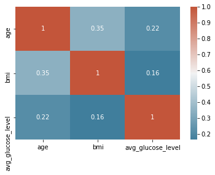

```
Plot of corelation matrix : patient had stroke
```

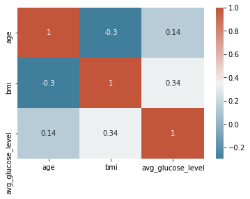

```python
def plot_corr_matrix(df, plot_name, pdf_name):
    result_path = os.path.join("./", pdf_name)
    cmap = sns.diverging_palette(230, 20, as_cmap=True)
    sns.heatmap(df,cmap=cmap, annot=True)
    plt.savefig(result_path,format = "pdf",bbox_inches="tight", pad_inches=0.1,dpi=300)
    plt.show()

df_stroke_0 = df_data_stroke[df_data_stroke['stroke'] == 0]
df_stroke_1 = df_data_stroke[df_data_stroke['stroke'] == 1]
features = ['age','bmi','avg_glucose_level']

df_0 = df_stroke_0[features]
df_1 = df_stroke_1[features]

corrMatrix_0 = df_0.corr()
corrMatrix_1 = df_1.corr()

print("Plot of corelation matrix : patient did not have stroke\n")
plot_corr_matrix(corrMatrix_0, 'plot_0', 'plot_0.pdf')

print("Plot of corelation matrix : patient had stroke\n")
plot_corr_matrix(corrMatrix_1, 'plot_1', 'plot_1.pdf')
```

### Inferences

- For patients with stroke, there exists moderate positive correlation of 0.34 between BMI and average glucose level.
- For patients with stroke, there exists moderate negative correlation of -0.3 between BMI and age.
- For patients without stroke, there exists moderate positive correlation of 0.35 between BMI and age.
- For patients without stroke, there exists moderate positive correlation of 0.22 between average glucose level and age.

### Pairwise plots for stroke = 0 and stroke = 1.

```
Stroke = NO
```

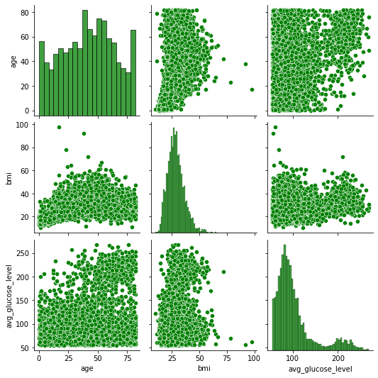

```
Stroke = YES
```

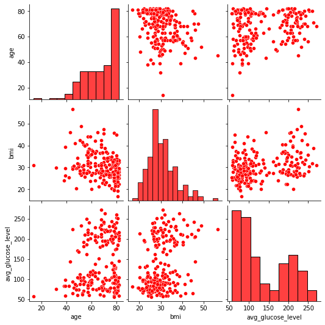

```python
def plot_graph(df, plot_name, pdf_name, color):

    # here =os. path . abspath ( __file__ )
    # plot_dir =os. path . abspath (os. path . join (here ,os. pardir ))
    plot_dir = os.path.join("./", pdf_name)
    colors = [color]
    cols = sns.set_palette(sns.color_palette(colors))
    plot_name = sns.pairplot(df,vars = cols)
    plt.show()
    plot_name.savefig(plot_dir)


features = ['age','bmi','avg_glucose_level','stroke']
X = df_data_stroke[features]
# Y = df_data_stroke['stroke label']
# X_train,X_test,Y_train,Y_test=train_test_split(X,Y,test_size=TEST_SIZE,random_state =RANDOM_STATE)

X_0 = X[X['stroke'] == 0]
X_1 = X[X['stroke'] == 1]
del X_0['stroke']
del X_1['stroke']

print("Stroke = NO")
plot_graph(X_0, 'pair_plot_stroke_0', 'stroke_0.pdf', 'green')
print("Stroke = YES")
plot_graph(X_1, 'pair_plot_stroke_1', 'stroke_1.pdf', 'red')
```

- Patients who have had a stroke are older and have higher BMI and average glucose level.

### Analyze features

Following 7 features are taken into account for analysis and a feature subset is created:

```
    1) gender: "Male", "Female" or "Other"
    2) age: age of the patient
    3) hypertension: 0 if the patient doesn't have hypertension, 1 if the patient has hypertension
    4) heart_disease: 0 if the patient doesn't have any heart diseases, 1 if the patient has a heart disease
    5) avg_glucose_level: average glucose level in blood
    6) bmi: body mass index
    7) smoking_status: "formerly smoked", "never smoked", "smokes" or "Unknown"*
```

```python
# Following 7 features are taken into account and a subset is created:
# age, hypertension, heart_disease, bmi, avg_glucose_level, gender, smoking_status
CATEGORICAL_FEATURES = ['gender','smoking_status']
NUMERICAL_FEATURES = ['age', 'hypertension','heart_disease','bmi','avg_glucose_level','stroke','stroke label']
```

### Encode categorical data

Stroke data set has both numeric and categorical features, therefore categorical features need to be converted into numerical features a method like one hot encoding.

```python
# Convert categorical features into dummy variables and combine them with numerical variables
def dataset_dummies(categrical_features, numerical_features):
    input_data_categorical = df_data_stroke[categrical_features]
    dummies = [pd.get_dummies(df_data_stroke[c]) for c in input_data_categorical.columns]
    binary_data = pd.concat(dummies, axis=1)
    df_result = binary_data.join(df_data_stroke[numerical_features])
    return (df_result)
```

### Balance dataset

Stroke prediction dataset is highly imbalanced. There are only 209 observation with stroke = 1 and 4700 observations with stroke = 0. A balanced sample dataset is created by combining all 209 observations with stroke = 1 and 10% of the observations with stroke = 0 which were obtained by random sampling from the 4700 observations. The resulting sample dataset is then split into train and test set. Different classifiers are trained on the train set and applied on the sample test set and then on the whole data set excluding train set.

```python
def sample_dataset(categrical_features, numerical_features, dummy):

    if dummy:
        df_result = dataset_dummies(categrical_features, numerical_features)
    else:
        df_result = df_data_stroke[numerical_features]

    # stroke event 0
    df_stroke0 = df_result[df_result['stroke'] == 0]
    # here you get 10 % of the rows of stroke event 0
    df_stroke0_sample = df_stroke0.sample(frac = 0.1, random_state = RANDOM_STATE)
    # stroke event 1
    df_stroke1 = df_result[df_result['stroke'] == 1]

    df_stroke = df_stroke1.append(df_stroke0_sample)

    col_no = len(df_stroke.columns)-2
    X = df_stroke.iloc[:, 0:col_no]
    Y = df_stroke['stroke label']

    le = LabelEncoder ()
    Y = le.fit_transform(Y)
    return (X, Y, df_result, col_no)

X, Y , df_result, COLUMN_NO = sample_dataset(CATEGORICAL_FEATURES, NUMERICAL_FEATURES, True)
X.shape, Y.shape
```

```
((679, 11), (679,))
```

### Evaluation metrics

#### Provided by Nabeel Shaikh (github.com/nshaikh99)

Accuracy tells us how often our model issues a correct prediction. This is accomplished by dividing the sum of the number of true positives and the number of true negatives by the number of total predictions. We value maximizing accuracy when we want to maximize the number of true positives and the number of true negatives.

Recall(TPR or Sensitivity) is the fraction of positive labels predicted correctly. It tells us how often our model doesn't issue a false negative prediction. This is accomplished by dividing the number of true positives by the sum of the number of true positives and the number of false negatives. We value maximizing recall when we want to minimize the number of false negatives. For example, we would want to maximize recall when predicting if someone has a life threatening disease.

Precision tells us how often our model doesn't issue a false positive prediction. This is accomplished by dividing the number of true positives by the sum of the number of true positives and the number of false positives. We value maximizing precision when we want to minimize the number of false positives. For example, we would want to maximize precision when predicting if someone is who they say they are when opening a credit card.

F1 score tells us how often our model doesn't issue a false positive or false negative prediction. This is accomplished by dividing two times recall times precision by the sum of recall and precision. We value maximizing F1 score when we want to minimize both the number of false positives and the number of false negatives. For example, we would want to maximize F1 score when predicting if someone committed a crime.

### KNN Classifier

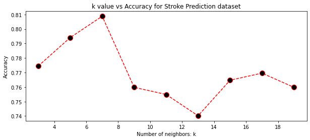

```
Optimal k =  7
Model Summary:

               Model    TP    FP    TN    FN    TPR    TNR  Accuracy%
                K_NN    35   722  3657    19    0.6    0.8       83.3
```

```python
# Train your K_NN classifier on a random sample X_train and compute its accuracy for X_test

# computes TP, FP, TN, FN
def model_eval(pred_label, true_label):
    true_positive = 0
    false_positive = 0
    false_negative = 0
    true_negative = 0
    for i in range(len(true_label)):
        if true_label[i] == 1:
            if pred_label[i] == 1:
                true_positive+=1
            else:
                false_negative+=1
        else:
            if pred_label[i] == 1:
                false_positive+=1
            else:
                true_negative+=1

    return(true_positive, false_positive, true_negative, false_negative)



# computes TPR = TP/(TP + FN) - true positive rate
def TPR_cal(TP, FP, TN, FN):
    TPR = TP / (TP + FN)
    return TPR


# computes TNR = TN/(TN + FP) - true negative rate
def TNR_cal(TP, FP, TN, FN):
    TNR = TN / (TN + FP)
    return TNR

# prints model summary
def print_model_summary(model_summary):

    row = 0
    print("%20s"%model_summary[row][0],"%5s"%model_summary[row][1],"%5s"%model_summary[row][2],
          "%5s"%model_summary[row][3],"%5s"%model_summary[row][4],"%6s"%model_summary[row][5],
          "%6s"%model_summary[row][6],"%10s"%model_summary[row][7])

    for row in range(1,len(model_summary)):
            print("%20s"%model_summary[row][0],"%5s"%model_summary[row][1],"%5s"%model_summary[row][2],
                  "%5s"%model_summary[row][3],"%5s"%model_summary[row][4],"{:6.1f}".format(model_summary[row][5]),
                  "{:6.1f}".format(model_summary[row][6]),"{:10.1f}".format(model_summary[row][7]))


# K_NN Classifier
def k_nn_classifier(X, Y, df_result, COLUMN_NO):
    error_rate = []
    accuracy_rate = []
    for k in [3,5,7,9,11,13,15,17,19]:
        # split the dataset into train and test set
        X_train ,X_test ,Y_train ,Y_test=train_test_split(X,Y,test_size=TEST_SIZE, random_state=RANDOM_STATE)
        X_train = X_train.values
        X_test = X_test.values

        # scale data
        scaler = StandardScaler().fit(X_train)
        X_train = scaler.transform(X_train)
        X_test = scaler.transform(X_test)

        # train K_NN classifier
        knn_classifier = KNeighborsClassifier(n_neighbors=k)
        knn_classifier.fit(X_train ,Y_train)

        # predict
        pred_k = knn_classifier.predict(X_test)
        accuracy_rate.append(np.mean(pred_k == Y_test))
        accuracy = np.mean(pred_k == Y_test)
        error_rate.append(np.mean(pred_k != Y_test))

        # print("Accuracy of prediction using k-NN classifier for k =",k,"is {:.1f}".format(accuracy*100),"%")


    # Plot a graph showing the accuracy
    plt.figure(figsize=(10,4))
    ax = plt.gca()
    plt.plot(range(3,20,2), accuracy_rate , color='red', linestyle='dashed',marker='o', markerfacecolor='black', markersize=10)
    plt.title('k value vs Accuracy for Stroke Prediction dataset')
    plt.xlabel('Number of neighbors: k')
    plt.ylabel('Accuracy')
    plt.show()

    # Use the optimal value k∗ to compute performance measures and summarize them in the table
    index = np.argmax(accuracy_rate, axis=0)
    k = index * 2 + 3
    print("Optimal k = ", k)
    le = LabelEncoder ()
    Y = le.fit_transform(Y)

    Xtrain ,Xtest ,Y_train ,Y_test=train_test_split(X,Y,test_size=TEST_SIZE,random_state=RANDOM_STATE)
    X_train = Xtrain.values
    X_test = Xtest.values

    scaler = StandardScaler().fit(X_train)
    X_train = scaler.transform(X_train)
    X_test = scaler.transform(X_test)


    knn_classifier = KNeighborsClassifier(n_neighbors=k)
    knn_classifier.fit(X_train ,Y_train)

    # subtract X_train from the entire dataset
    df = df_result[~df_result.index.isin(Xtrain.index)]
    X_test = df.iloc[:, 0:COLUMN_NO].values
    Y_test = df['stroke label'].values

    # apply K_NN classifier trained on the sample training set to the entire dataset
    X_test = scaler.transform(X_test)
    Y_test = le.fit_transform(Y_test)

    pred_k = knn_classifier.predict(X_test)
    knn_accuracy = np.mean(pred_k == Y_test)

    (TP, FP, TN, FN) = model_eval(list(pred_k), list(Y_test))
    TPR = TPR_cal(TP, FP, TN, FN)
    TNR = TNR_cal(TP, FP, TN, FN)

    # Summarize KNN classifier performance measures on the entire dataset in a table
    knn_classifier_summary_dataset= []
    knn_classifier_summary_dataset.append(COLUMN_HEADING)

    knn_classifier_summary_dataset.append(['K_NN', TP, FP, TN, FN, TPR, TNR, knn_accuracy * 100])
    classifier_summary_dataset.append(['K_NN', TP, FP, TN, FN, TPR, TNR, knn_accuracy * 100])
    print("Model Summary:\n")
    print_model_summary(knn_classifier_summary_dataset)

k_nn_classifier(X, Y, df_result, COLUMN_NO)
```

### Logistic Regression Classfier

```python
# Train your logistic regression classifier on a random sample X_train and compute its accuracy for X_test

def logistic_reg_classifier(X, Y, df_result, COLUMN_NO):

    # print("\nLogistic Regression Classifier:\n")
    le = LabelEncoder ()
    Y = le.fit_transform(Y)

    Xtrain ,Xtest ,Y_train ,Y_test = train_test_split(X,Y,test_size=TEST_SIZE,random_state=RANDOM_STATE)

    X_train = Xtrain.values
    X_test = Xtest.values

    scaler = StandardScaler().fit(X_train)
    X_train = scaler.transform(X_train)
    X_test = scaler.transform(X_test)

    log_reg_classifier = LogisticRegression()
    log_reg_classifier.fit(X_train, Y_train)


    # Subtract X_train from the entire dataset

    df = df_result[~df_result.index.isin(Xtrain.index)]
    X_test = df.iloc[:, 0:COLUMN_NO].values
    Y_test = df['stroke label'].values

    #Apply logistic regression classifier trained on the sample X_train to the entire dataset

    X_test = scaler.transform(X_test)
    Y_test = le.fit_transform(Y_test)

    prediction = log_reg_classifier.predict(X_test)
    # log_reg_accuracy = np.mean(prediction == Y_test)
    log_reg_accuracy = log_reg_classifier.score(X_test, Y_test)

    (TP, FP, TN, FN) = model_eval(list(prediction), list(Y_test))
    TPR = TPR_cal(TP, FP, TN, FN)
    TNR = TNR_cal(TP, FP, TN, FN)

    # Summarize logistic regression classifier performance measures on the entire dataset in a table

    log_reg_summary_dataset = []
    log_reg_summary_dataset.append(COLUMN_HEADING)

    log_reg_summary_dataset.append(['Logistic Regression', TP, FP, TN, FN, TPR, TNR, log_reg_accuracy*100])
    classifier_summary_dataset.append(['Logistic Regression', TP, FP, TN, FN, TPR, TNR, log_reg_accuracy * 100])
    print("Model Summary:\n")
    print_model_summary(log_reg_summary_dataset)

logistic_reg_classifier(X, Y, df_result, COLUMN_NO)
```

```
Model Summary:

               Model    TP    FP    TN    FN    TPR    TNR  Accuracy%
 Logistic Regression    41   764  3615    13    0.8    0.8       82.5
```

### Decision Tree Classifier

```python
# train Decision Tree Classifier on X_train and predict class labels in X_test.

def decision_tree_classifier(X, Y, df_result, COLUMN_NO):

    le = LabelEncoder ()
    Y = le.fit_transform(Y)

    # Split your sample dataset 70/30,
    Xtrain ,Xtest ,Y_train ,Y_test = train_test_split(X,Y, test_size=TEST_SIZE,random_state=RANDOM_STATE)
    X_train = Xtrain.values
    X_test = Xtest.values
    tree_classifier = tree.DecisionTreeClassifier(criterion = 'entropy')
    tree_classifier = tree_classifier.fit(X_train, Y_train)

    # Subtract X_train from the entire dataset
    df = df_result[~df_result.index.isin(Xtrain.index)]
    X_test = df.iloc[:, 0:COLUMN_NO].values
    Y_test = df['stroke label'].values
    Y_test = le.fit_transform(Y_test)

    # Apply Decision Tree classifier trained on the sample X_train to the entire dataset
    prediction = tree_classifier.predict(X_test)
    error_rate = np.mean(prediction != Y_test)
    DT_accuracy = np.mean(prediction == Y_test)

    cf = sk.confusion_matrix(Y_test, prediction)

    (TP, FP, TN, FN) = model_eval(list(prediction), list(Y_test))
    TPR = TPR_cal(TP, FP, TN, FN)
    TNR = TNR_cal(TP, FP, TN, FN)

    decision_tree_dataset = []
    decision_tree_dataset.append(COLUMN_HEADING)

    decision_tree_dataset.append(['Decision Tree', TP, FP, TN, FN, TPR, TNR, DT_accuracy * 100])
    classifier_summary_dataset.append(['Decision Tree', TP, FP, TN, FN, TPR, TNR, DT_accuracy * 100])
    print("Model Summary:\n")
    print_model_summary(decision_tree_dataset)

decision_tree_classifier(X, Y, df_result, COLUMN_NO)
```

```
Model Summary:

               Model    TP    FP    TN    FN    TPR    TNR  Accuracy%
       Decision Tree    40  1049  3330    14    0.7    0.8       76.0
```

### Random Forest Classifier

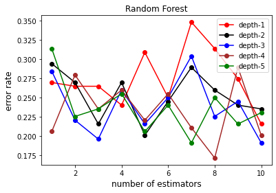

[output not shown]

```python
# train Random Forest Classifier on X_train and predict class labels in X_test.
def random_forest_classifier(X, Y, df_result, COLUMN_NO):

    # print("\nRandom Forest Classifier:\n")
    le = LabelEncoder ()
    Y = le.fit_transform(Y)

    for d, color in enumerate (['red', 'black', 'blue', 'brown', 'green'], start=1):
        error_rate = np.empty([])

        for N in range(1,11):
            X_train ,X_test ,Y_train ,Y_test = train_test_split(X,Y, test_size=TEST_SIZE)
            X_train = X_train.values
            X_test = X_test.values
            model = RandomForestClassifier(n_estimators = N, max_depth = d, criterion='entropy')
            model.fit(X_train , Y_train)
            prediction = model.predict(X_test)
            error = np.mean(prediction != Y_test)
            # print('\nestimator:', N, model.estimators_[N-1])
            # print('error rate:',error)
            error_rate  = np.append(error_rate,np.mean(prediction != Y_test))

        error_rate = np.delete(error_rate, 0)
        N_values = np.arange(1,11)
        plt.plot(N_values, error_rate , "-o",  color=color, label = "depth-"+str(d))
        plt.legend()


    # Plot error rates and find the best combination of N and d.
    plt.xlabel("number of estimators", fontsize=12)
    plt.ylabel("error rate", fontsize=12)
    plt.title("Random Forest")
    plt.show()

    N = 10
    d = 4

    print("Plot shows that the best combination of number of estimators(sub trees) and depth of tree is:")
    print("estimators(sub trees) = ", N)
    print("depth of tree = ", d)
    print()

    Xtrain ,Xtest ,Y_train ,Y_test = train_test_split(X,Y, test_size=TEST_SIZE, random_state = RANDOM_STATE)
    X_train = Xtrain.values
    X_test = Xtest.values
    model = RandomForestClassifier(n_estimators = N, max_depth = d, criterion='entropy')
    model.fit(X_train , Y_train)

    # Subtract X_train from the entire dataset
    df = df_result[~df_result.index.isin(Xtrain.index)]
    X_test = df.iloc[:, 0:COLUMN_NO].values
    Y_test = df['stroke label'].values

    # Apply Random Forest classifier trained on the sample X_train to the entire dataset
    Y_test = le.fit_transform(Y_test)

    prediction = model.predict(X_test)
    error_rate = np.mean(prediction != Y_test)
    rf_accuracy = np.mean(prediction == Y_test)

    cf = sk.confusion_matrix(Y_test, prediction)

    (TP, FP, TN, FN) = model_eval(list(prediction), list(Y_test))
    TPR = TPR_cal(TP, FP, TN, FN)
    TNR = TNR_cal(TP, FP, TN, FN)

    random_forest_dataset = []
    random_forest_dataset.append(COLUMN_HEADING)

    random_forest_dataset.append(['Random Forest', TP, FP, TN, FN, TPR, TNR, rf_accuracy * 100])
    classifier_summary_dataset.append(['Random Forest', TP, FP, TN, FN, TPR, TNR, rf_accuracy * 100])
    print("Model Summary:\n")
    print_model_summary(random_forest_dataset)

random_forest_classifier(X, Y, df_result, COLUMN_NO)
```

### Summary of performance measures using different classifiers on the whole dataset with the following features:

```python
print_model_summary(classifier_summary_dataset)
```

```
               Model    TP    FP    TN    FN    TPR    TNR  Accuracy%
                K_NN    35   722  3657    19    0.6    0.8       83.3
 Logistic Regression    41   764  3615    13    0.8    0.8       82.5
       Decision Tree    40  1049  3330    14    0.7    0.8       76.0
       Random Forest    30   645  3734    24    0.6    0.9       84.9
```

## Feature selection: gender feature is missing

Gender feature is dropped from the dataset to see its impact on the accuracy of prediction. Classifiers are trained on the ”truncated” training set using the remaining features and are used to predict labels on test set.

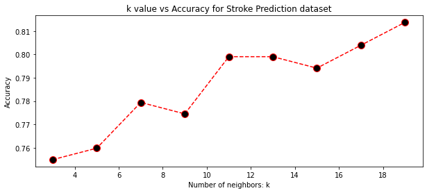

```
Optimal k =  19
Model Summary:

               Model    TP    FP    TN    FN    TPR    TNR  Accuracy%
                K_NN    31   613  3766    23    0.6    0.9       85.7
Model Summary:

               Model    TP    FP    TN    FN    TPR    TNR  Accuracy%
 Logistic Regression    40   750  3629    14    0.7    0.8       82.8
Model Summary:

               Model    TP    FP    TN    FN    TPR    TNR  Accuracy%
       Decision Tree    38  1022  3357    16    0.7    0.8       76.6
```

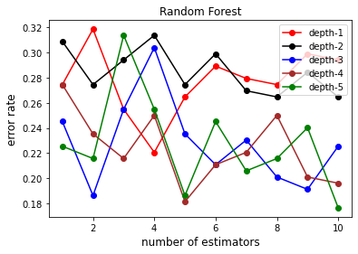

[output not shown]

```python
CATEGORICAL_FEATURES = ['smoking_status']
NUMERICAL_FEATURES = ['age', 'hypertension','heart_disease','bmi','avg_glucose_level','stroke','stroke label']
"""
create two lists to store summary of all the classifiers applied to the sample data
and to store summary of all the classifiers applied to the whole dataset.
"""
classifier_summary_dataset = []
classifier_summary_dataset.append(COLUMN_HEADING)

X, Y , df_result, COLUMN_NO = sample_dataset(CATEGORICAL_FEATURES, NUMERICAL_FEATURES, True)

# classifiers
k_nn_classifier(X, Y, df_result, COLUMN_NO)
logistic_reg_classifier(X, Y, df_result, COLUMN_NO)
decision_tree_classifier(X, Y, df_result, COLUMN_NO)
random_forest_classifier(X, Y, df_result, COLUMN_NO)

print("Summary of performance measures using different classifiers on the whole dataset excluding sample train-set:\n")
print_model_summary(classifier_summary_dataset)
```

## Prediction using lime package

LIME algorithm is used to explain the predictions of Logistic Regression classifier. Lime explains the prediction by approximating it locally with an interpretable model.

### Analyze features

10 clinical features are used:

```
1) gender: "Male", "Female" or "Other"
2) age: age of the patient
3) hypertension: 0 if the patient doesn't have hypertension, 1 if the patient has hypertension
4) heart_disease: 0 if the patient doesn't have any heart diseases, 1 if the patient has a heart disease
5) ever_married: "No" or "Yes"
6) work_type: "children", "Govt_jov", "Never_worked", "Private" or "Self-employed"
7) Residence_type: "Rural" or "Urban"
8) avg_glucose_level: average glucose level in blood
9) bmi: body mass index
10) smoking_status: "formerly smoked", "never smoked", "smokes" or "Unknown"*
```

### Data preprocessing

create a copy of original dataframe and remove features id and stroke label from the dataset

```python
# create a copy of original dataframe and remove features id and stroke label from the dataset
df_stroke_data = df_data_stroke.copy()
del df_stroke_data['id']
del df_stroke_data['stroke label']
```

### Encode categorical data¶

```python
# get dummy variables for all categorical features
df_stroke_data = pd.get_dummies(df_stroke_data)
```

### Balance dataset

Stroke prediction dataset is highly imbalanced. There are only 209 observation with stroke = 1 and 4700 observations with stroke = 0. A balanced sample dataset is created by combining all 209 observations with stroke = 1 and 10% of the observations with stroke = 0 which were obtained by random sampling from the 4700 observations. The resulting sample dataset is then split into train and test set. Different classifiers are trained on the train set and applied on the sample test set and then on the whole data set excluding train set.

```python
# stroke event 0 (no stroke)
df_stroke0 = df_stroke_data[df_stroke_data['stroke'] == 0]
# here you get 10 % of the rows of stroke event 0
df_stroke0_sample = df_stroke0.sample(frac = 0.1, random_state = RANDOM_STATE)
# stroke event 1 (stroke)
df_stroke1 = df_stroke_data[df_stroke_data['stroke'] == 1]
# create a balanced sample dataset by combining 209 obsetvations for stroke = 1 and 10% of the observations for stroke = 0
df_stroke_sample = df_stroke1.append(df_stroke0_sample)

Y = df_stroke_sample['stroke']
X = df_stroke_sample.copy()

target_names = ['no stroke', 'stroke']

print("\nData Size of sample dataset: ", X.shape, Y.shape)
```

```
Data Size of sample dataset:  (679, 21) (679,)
```

### Logistic Regression

```python
# split sample dataset into training and testing sets using 70/30 split
Xtrain, Xtest, Y_train, Y_test = train_test_split(X, Y, train_size=0.7, test_size=0.3, stratify=Y, random_state=3)

X_train = Xtrain.copy()
del X_train['stroke']
column_names = list(X_train.columns)
X_train = X_train.values
X_test = Xtest.copy()
del X_test['stroke']
X_test = X_test.values
Y_train = Y_train.values
Y_test = Y_test.values

# scale train and test set
scaler = StandardScaler().fit(X_train)
X_train = scaler.transform(X_train)
X_test = scaler.transform(X_test)

print("\nTrain set size and shape : ", X_train.shape, Y_train.shape)
print("\nTest set size and shape  : ", X_test.shape, Y_test.shape)

# Logistic Regression Classifier
lr = LogisticRegression()
lr.fit(X_train, Y_train)

# Subtract X_train from the entire dataset to get the testing set
df = df_stroke_data[~df_stroke_data.index.isin(Xtrain.index)]
Y_test = df['stroke'].values
df_X_test = df.copy()
del df['stroke']
X_test = df.values

# Apply logistic regression classifier trained on the sample X_train to the entire dataset
X_test = scaler.transform(X_test)

print("\nLogistic Regression Classifier:\n")
print("Test  Accuracy test set : %.2f"%lr.score(X_test, Y_test))
print("Train Accuracy train set : %.2f"%lr.score(X_train, Y_train))
print()
print("Confusion Matrix : ")
print(confusion_matrix(Y_test, lr.predict(X_test)))
print()
print("Classification Report")
print(classification_report(Y_test, lr.predict(X_test)))
```

```
Train set size and shape :  (475, 20) (475,)

Test set size and shape  :  (204, 20) (204,)

Logistic Regression Classifier:

Test  Accuracy test set : 0.84
Train Accuracy train set : 0.83

Confusion Matrix :
[[3683  687]
 [  26   37]]

Classification Report
              precision    recall  f1-score   support

           0       0.99      0.84      0.91      4370
           1       0.05      0.59      0.09        63

    accuracy                           0.84      4433
   macro avg       0.52      0.72      0.50      4433
weighted avg       0.98      0.84      0.90      4433
```

### LIME explanation of prediction of logistic regression classifier

The explanation of LIME provides an intuition into the inner workings of machine learning algorithms as to what features are being used to arrive at a prediction. It assigns weight to each feature based on its contribution to the prediction of a label within the local structure of the data.

[output not shown]

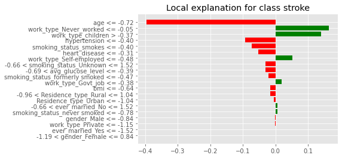

```python
# Lime

explainer = lime_tabular.LimeTabularExplainer(X_train, mode="classification",
                                              class_names=target_names,
                                              feature_names=column_names,
                                              )

print(explainer)
print()

# Randomly pick a patient from the dataset for prediction
idx = random.randint(1, len(X_test))

# stroke
# idx = 11

# no stroke
# idx = 100

print('A patient picked randomly from the dataset for prediction is at index = ',idx)
print("Prediction: ", target_names[lr.predict(X_test[idx].reshape(1,-1))[0]])
print("Actual:     ", target_names[Y_test[idx]])

explanation_lr = explainer.explain_instance(X_test[idx], lr.predict_proba,
                                          num_features=len(column_names))
with plt.style.context("ggplot"):
    explanation_lr.as_pyplot_figure()

# method for classification
print("\nExplanation of prediction using Logistic Regression Classifier:\n")
print(explanation_lr.as_map())

html_data = explanation_lr.as_html()
HTML(data=html_data)

explanation_lr.save_to_file("logreg_classification_explanation.html")
```